# (New) DADA2 pipeline on A1 data

Michael McLaren

2020-11-06

This document re-analyzes the amplicon data from the A1 sequencing center following the modified the DADA2 Pipeline used for the A2 data.

## Setup

Load the libraries

```r
library(here)
library(tidyverse)
library(fs)
library(dada2); packageVersion("dada2")
```

```
## [1] '1.18.0'
```

```r
import::from(Biostrings, complement, reverseComplement, width, DNAString,
  readDNAStringSet)
import::from(DECIPHER, TrimDNA)
```

Path for saving dada2 results:

```r
results_path <- here("output", "a1", "dada2")
dir.create(results_path, recursive = TRUE)
```

Path to the fastq files:

```r
reads_path <- here("data", "a1", "reads")
dir_ls(path(reads_path, "raw")) %>% path_file %>% head
```

```
## [1] "1-1_S28_L001_R1_001.fastq.gz"  "1-1_S28_L001_R2_001.fastq.gz"
## [3] "1-2_S69_L001_R1_001.fastq.gz"  "1-2_S69_L001_R2_001.fastq.gz"
## [5] "10-1_S16_L001_R1_001.fastq.gz" "10-1_S16_L001_R2_001.fastq.gz"
```

Let’s get a data frame with the sample names, paths to the raw reads, and paths to the (to-be-created) filtered reads.

```r
ftb <- tibble(path = dir_ls(path(reads_path, "raw"), glob = "*.fastq.gz")) %>%
  mutate(
    read_direction = case_when(
      str_detect(path, "_R1_") ~ "R1",
      str_detect(path, "_R2_") ~ "R2"
    ),
    fastq_sample_id = str_extract(path %>% path_file, "[^_]+"),
    dna_sample_id = str_replace(fastq_sample_id, "-", "_") %>% str_to_lower,
    sample_id = str_c("A1_", dna_sample_id),
    path_filt = path(reads_path, "filtered",
      str_glue("{fastq_sample_id}_{read_direction}_filt.fastq.gz")
    )
  ) %>%
  pivot_wider(names_from = read_direction, values_from = c(path, path_filt))
# Check
ftb %>% head %>% mutate(across(starts_with("path"), path_file)) %>% glimpse
```

```
## Rows: 6
## Columns: 7
## $ fastq_sample_id <chr> "1-1", "1-2", "10-1", "10-2", "10-3", "10-4"
## $ dna_sample_id   <chr> "1_1", "1_2", "10_1", "10_2", "10_3", "10_4"
## $ sample_id       <chr> "A1_1_1", "A1_1_2", "A1_10_1", "A1_10_2", "A1_1…
## $ path_R1         <chr> "1-1_S28_L001_R1_001.fastq.gz", "1-2_S69_L001_R…
## $ path_R2         <chr> "1-1_S28_L001_R2_001.fastq.gz", "1-2_S69_L001_R…
## $ path_filt_R1    <chr> "1-1_R1_filt.fastq.gz", "1-2_R1_filt.fastq.gz",…
## $ path_filt_R2    <chr> "1-1_R2_filt.fastq.gz", "1-2_R2_filt.fastq.gz",…
```

## Check sequences

Let’s inspect the sequences for one sample,

```r
reads <- ftb %>%
  filter(dna_sample_id == "5_1") %>%
  select(R1 = path_R1, R2 = path_R2) %>%
  c %>%
  map(readDNAStringSet, format = "fastq")
reads
```

```
## $R1
## DNAStringSet object of length 82449:
##         width seq                                     names
##     [1]   251 TACGGAGGATCCGAGCGT...AAGTGTGGGTATCAAACA M02127:24:0000000...
##     [2]   251 TACAGAGGTCTCAAGCGT...AGGCCAGGGGAGCGAAAG M02127:24:0000000...
##     [3]   251 TACAGAGGTCTCAAGCGT...AGGCCAGGGGAGCGAAAG M02127:24:0000000...
##     [4]   251 TACGGAGGATCCGAGCGT...AAGTGTGGGTATCAAACA M02127:24:0000000...
##     [5]   251 TACGGAGGATCCGAGCGT...AAGTGTGGGTATCAAACA M02127:24:0000000...
##     ...   ... ...
## [82445]   251 TACAGAGGTCTCAAGCGT...AGACCAGGGGAGCGAAAG M02127:24:0000000...
## [82446]   251 TACGGAGGATCCGAGCGT...AAGTGTGGGTAGCAAACA M02127:24:0000000...
## [82447]   251 TACAGAGGTCTCAAGCGT...AGGCCAGGGGAGCGAAAG M02127:24:0000000...
## [82448]   251 TACGGAGGATCCGAGCGT...AAGTGTGGGTATCAAACA M02127:24:0000000...
## [82449]   251 TACGGAGGTTCCGAGCGT...AAGTGTGGGTATCAAACA M02127:24:0000000...
##
## $R2
## DNAStringSet object of length 82449:
##         width seq                                     names
##     [1]   251 CCTGTTTGATACCCACAC...TAACGCTCGGATCCTCCG M02127:24:0000000...
##     [2]   248 CCCTTTCGCTCCCCTGGC...GTACAACGCTTGAGTCCT M02127:24:0000000...
##     [3]   248 CCCTTTCGCTCCCCTGGC...GAACAACGCTTGAGACCT M02127:24:0000000...
##     [4]   251 CCTGTTTGATACCCACAC...TAACGCTCGGATCCTCCG M02127:24:0000000...
##     [5]   251 CCTGTTTGATACCCACAC...TAACGCTCGGATCCTCCG M02127:24:0000000...
##     ...   ... ...
## [82445]   248 CCCTTTCGATCCCCTGGT...GAACAACGCTTGAGACCT M02127:24:0000000...
## [82446]   251 CCTGTTTGATACCCACAC...TAACGCTCGGATCCTACG M02127:24:0000000...
## [82447]   248 CCCTTTTGCTACCCTGGC...GAACAACGCTTGAGACCT M02127:24:0000000...
## [82448]   251 CCTGTTTGATACCCACAC...TAACGCTCGGATCCTCCG M02127:24:0000000...
## [82449]   251 CCTGTTTGATACCCACAC...TACCGCTCGGATCCTCCG M02127:24:0000000...
```

As expected for this protocol, the primer sequences are not present in the reads.

```r
primers <- c(
  R1 = "GTGCCAGCMGCCGCGGTAA",
  R2 = "TAATCTWTGGGVHCATCAGG"
)
trim_left <- c(R1 = 0, R2 = 0)
```

### Check length of amplicon region

Load the 16S sequences that were extracted from the reference whole genomes,

```r
dna <- Biostrings::readDNAStringSet(
  here("output", "strain-data", "reference-16s-genes.fasta")
)
```

and extraction with `DECIPHER::TrimDNA()`

```r
primers.dna <- primers %>% map(DNAString)
x <- TrimDNA(dna, primers.dna[[1]], primers.dna[[2]] %>% complement,
  type = "sequences")
```

```
## Finding left pattern: 81% internal, 0% flanking
##
## Finding right pattern: 81% internal, 0% flanking
##
## Time difference of 0.08 secs
```

```r
width(x) %>% summary
```

```
##    Min. 1st Qu.  Median    Mean 3rd Qu.    Max.
##    60.0   253.0   253.0   240.2   253.0   537.0
```

```r
width(x) %>% table
```

```
## .
##  60  61  62  74  75  86 110 175 183 197 199 220 253 254 354 360 380 537
##   1   1   1   1   1   2   1   1   1   1   1   1  64   3   1   1   1   1
```

Note, primer sequences are trimmed from the output sequences. The true length of the amplicon is 253-254 bp bp *excluding* the primer sequences.

## Pick truncation params

We can’t use Figaro here because of a bug when primers aren’t sequenced, so I’ll stick to picking truncation parameters the old fashioned way (manually inspecting the quality profiles).

In fact, this was already done in the first run of DADA2 on this dataset, which used the following parameters:

```r
target_len <- 260
trunc_len <- c(230, 215)
# Overlap
sum(trunc_len) - sum(trim_left) - target_len
```

```
## [1] 185
```

This seems like a gratuitous amount of overlap - we can trim much more.

Let’s check some quality profiles with a new candidate trunc params.

```r
set.seed(42)
idx <- sample(nrow(ftb), 9)
idx
```

```
## [1] 49 65 25 74 18 96 47 24 71
```

```r
ftb %>% slice(idx) %>% pull(sample_id)
```

```
## [1] "A1_21_3"      "A1_26_3"      "A1_16_3"      "A1_4_4"
## [5] "A1_14_4"      "A1_zymo_posc" "A1_21_1"      "A1_16_2"
## [9] "A1_4_1"
```

```r
qps <- ftb %>%
  slice(idx) %>%
  select(R1 = path_R1, R2 = path_R2) %>%
  c %>%
  map(plotQualityProfile)
```

```r
trunc_len <- c(145, 145)
sum(trunc_len) - sum(trim_left) - target_len
```

```
## [1] 30
```

```r
p1 <- qps[["R1"]] +
  geom_hline(yintercept = 30, color = "grey") +
  geom_vline(xintercept = trunc_len[1], color = "darkred") +
  ggtitle("Forward reads")
p2 <- qps[["R2"]] +
  geom_hline(yintercept = 30, color = "grey") +
  geom_vline(xintercept = trunc_len[2], color = "darkred") +
  ggtitle("Reverse reads")
```

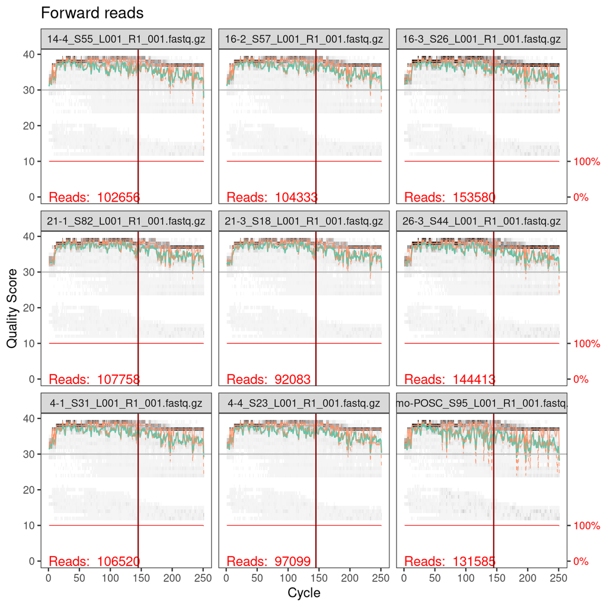

```r
p1
```

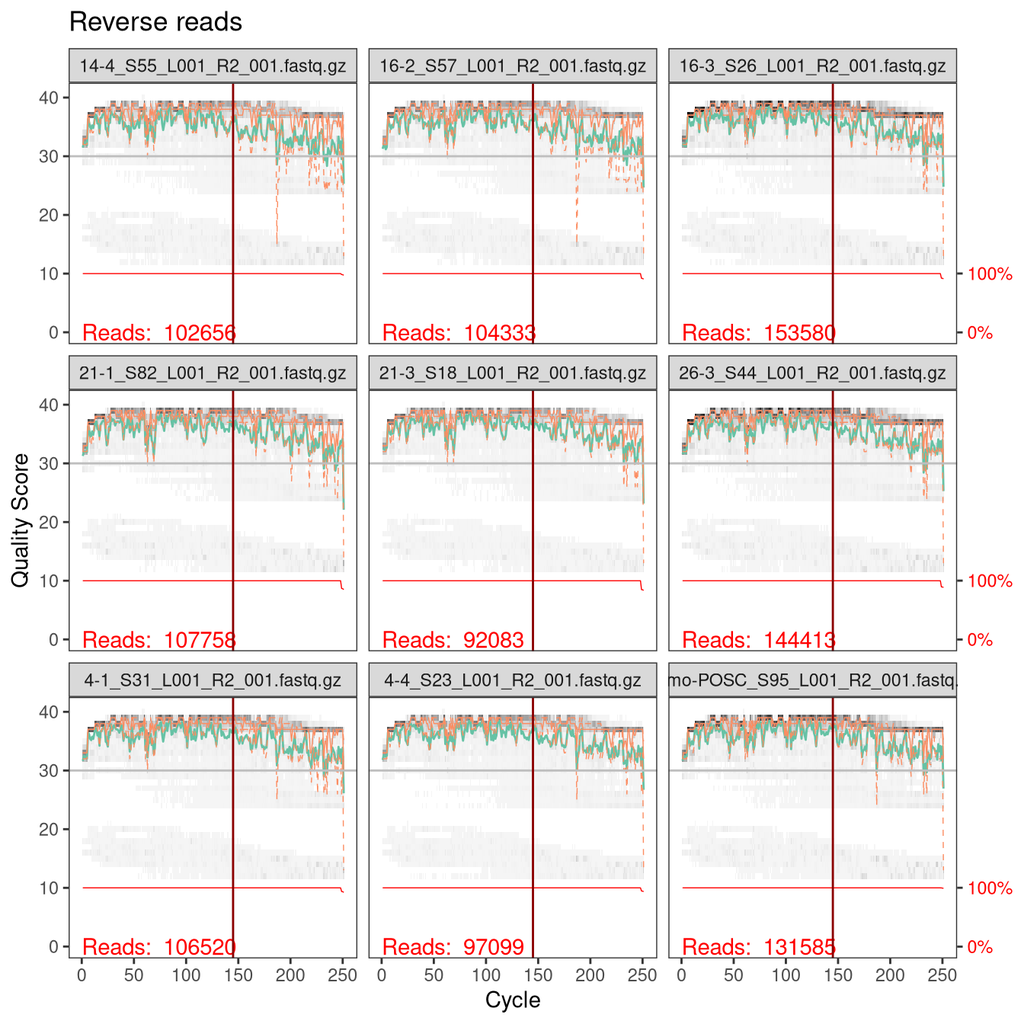

```r
p2
```

```r
ggsave(plot = p1, file.path(results_path, "quality-profiles-r1.pdf"),
    width = 10, height = 10, units = "in")
ggsave(plot = p2, file.path(results_path, "quality-profiles-r2.pdf"),
    width = 10, height = 10, units = "in")
```

## Filter and trim

First, delete the filtered reads from the initial run,

```r
dir_exists(path(reads_path, "filtered"))
```

```
## /home/michael/research/vivo-vitro/main/data/a1/reads/filtered
##                                                          TRUE
```

```r
dir_delete(path(reads_path, "filtered"))
```

and set up a lists with the paths to the forward and reverse reads (raw and filtered). Note, the file paths are named by sample id so that later DADA2 functions will name the samples by sample id instead of file name.

```r
path_raw <- list(R1 = ftb$path_R1, R2 = ftb$path_R2) %>%
  map(set_names, ftb$sample_id)
path_filt <- list(R1 = ftb$path_filt_R1, R2 = ftb$path_filt_R2) %>%
  map(set_names, ftb$sample_id)
# Check
path_filt %>% map(tail, 4) %>% map(names)
```

```
## $R1
## [1] "A1_9_3"        "A1_9_4"        "A1_water_negc" "A1_zymo_posc"
##
## $R2
## [1] "A1_9_3"        "A1_9_4"        "A1_water_negc" "A1_zymo_posc"
```

```r
path_filt %>% map(tail, 4) %>% map(path_file)
```

```
## $R1
## [1] "9-3_R1_filt.fastq.gz"        "9-4_R1_filt.fastq.gz"
## [3] "Water-NEGC_R1_filt.fastq.gz" "Zymo-POSC_R1_filt.fastq.gz"
##
## $R2
## [1] "9-3_R2_filt.fastq.gz"        "9-4_R2_filt.fastq.gz"
## [3] "Water-NEGC_R2_filt.fastq.gz" "Zymo-POSC_R2_filt.fastq.gz"
```

Then filter and trim.

```r
max_ee <- c(R1 = 2, R2 = 2)
out <- filterAndTrim(
  path_raw[[1]], path_filt[[1]],
  path_raw[[2]], path_filt[[2]],
  trimLeft = trim_left, truncLen = trunc_len,
  maxN = 0, maxEE = max_ee, truncQ = 2, rm.phix = TRUE,
  compress = TRUE, multithread = TRUE)
```

```
## Creating output directory: /home/michael/research/vivo-vitro/main/data/a1/reads/filtered
```

```r
head(out)
```

```
##                               reads.in reads.out
## 1-1_S28_L001_R1_001.fastq.gz     71156     70503
## 1-2_S69_L001_R1_001.fastq.gz    106556    105242
## 10-1_S16_L001_R1_001.fastq.gz    72544     72142
## 10-2_S14_L001_R1_001.fastq.gz   111752    110911
## 10-3_S21_L001_R1_001.fastq.gz   109313    108524
## 10-4_S76_L001_R1_001.fastq.gz    88758     88166
```

```r
# Save in case of crash downstream
saveRDS(out, file.path(results_path, "filt-out.Rds"))
```

## Learn the error rates

```r
errs <- path_filt %>%
  map(learnErrors, multithread = TRUE)
```

```
## 109463255 total bases in 754919 reads from 8 samples will be used for learning the error rates.
## 109463255 total bases in 754919 reads from 8 samples will be used for learning the error rates.
```

```r
saveRDS(errs, file.path(results_path, "error-models.Rds"))
```

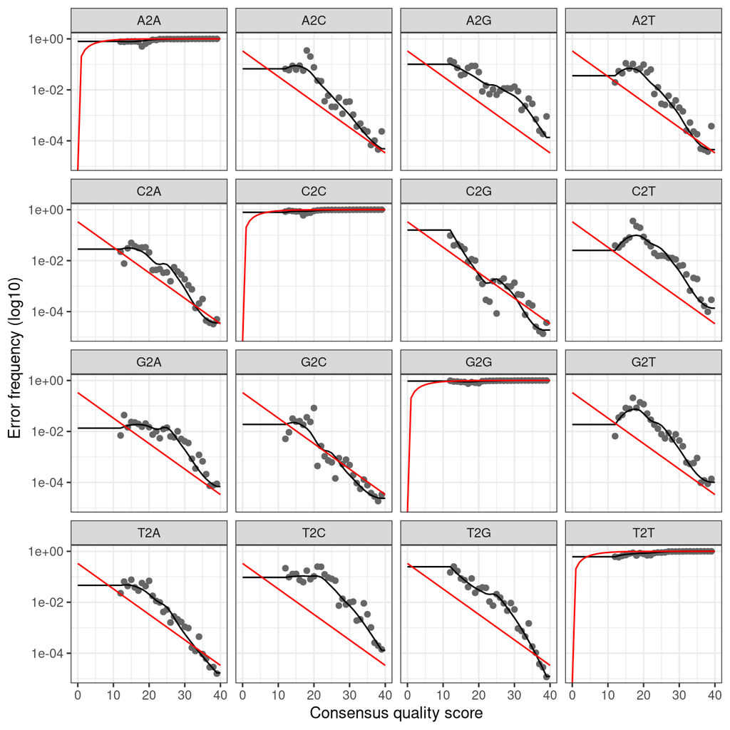

```r
plotErrors(errs[[1]], nominalQ = TRUE)
```

```r
ggsave(file.path(results_path, "error-profile-r1.pdf"),
    width = 9, height = 9, units = "in")
```

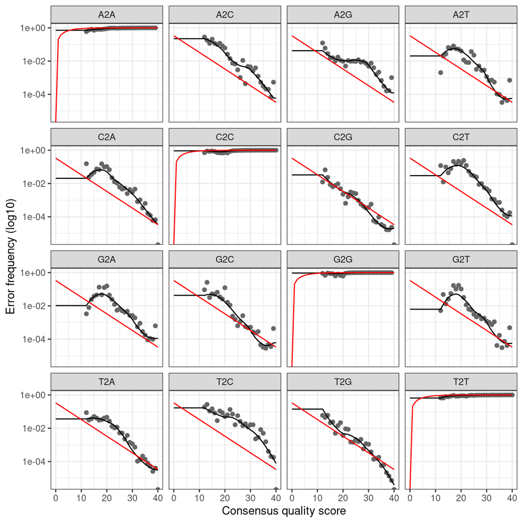

```r
plotErrors(errs[[2]], nominalQ = TRUE)
```

```r
ggsave(file.path(results_path, "error-profile-r2.pdf"),
    width = 9, height = 9, units = "in")
```

## Sample inference

The following settings for the `dada()` inference step are used:

- Pseudo-pooling used to increase sensitivity
  - `pool = "pseudo"` option
  - `PSEUDO_PREVALENCE = 4` (increased from default of 2 to reduce the number of spurious low-prev ASVs seen in the pilot)
- The inference step (`dada()`) is run two different ways: The default settings, and with `OMEGA_C = 2` (which prevents error correction, so that we can assign abundances using just the error-free read-pairs).

### Default `OMEGA_C`

Sample inference w/ `dada()`

```r
dadas <- map2(
  path_filt,
  errs,
  dada,
  multithread = TRUE, pool = "pseudo",
  PSEUDO_PREVALENCE = 4
)
```

```
## Sample 1 - 70503 reads in 4400 unique sequences.
## Sample 2 - 105242 reads in 8034 unique sequences.
## Sample 3 - 72142 reads in 6593 unique sequences.
## Sample 4 - 110911 reads in 8757 unique sequences.
## Sample 5 - 108524 reads in 8845 unique sequences.
## Sample 6 - 88166 reads in 7390 unique sequences.
## Sample 7 - 81896 reads in 6568 unique sequences.
## Sample 8 - 117535 reads in 9197 unique sequences.
## Sample 9 - 108836 reads in 8527 unique sequences.
## Sample 10 - 121228 reads in 9574 unique sequences.
## Sample 11 - 123249 reads in 9629 unique sequences.
## Sample 12 - 135617 reads in 9657 unique sequences.
## Sample 13 - 93263 reads in 5573 unique sequences.
## Sample 14 - 72126 reads in 4209 unique sequences.
## Sample 15 - 119789 reads in 12350 unique sequences.
## Sample 16 - 122158 reads in 13998 unique sequences.
## Sample 17 - 118837 reads in 12190 unique sequences.
## Sample 18 - 100983 reads in 11813 unique sequences.
## Sample 19 - 145029 reads in 12742 unique sequences.
## Sample 20 - 115723 reads in 11926 unique sequences.
## Sample 21 - 107329 reads in 10607 unique sequences.
## Sample 22 - 111886 reads in 11401 unique sequences.
## Sample 23 - 119006 reads in 11550 unique sequences.
## Sample 24 - 103059 reads in 11478 unique sequences.
## Sample 25 - 152104 reads in 14308 unique sequences.
## Sample 26 - 155852 reads in 15946 unique sequences.
## Sample 27 - 141103 reads in 10741 unique sequences.
## Sample 28 - 118309 reads in 9491 unique sequences.
## Sample 29 - 75471 reads in 6141 unique sequences.
## Sample 30 - 95361 reads in 7910 unique sequences.
## Sample 31 - 133974 reads in 11136 unique sequences.
## Sample 32 - 131979 reads in 10304 unique sequences.
## Sample 33 - 108706 reads in 8906 unique sequences.
## Sample 34 - 121308 reads in 9695 unique sequences.
## Sample 35 - 136143 reads in 10588 unique sequences.
## Sample 36 - 106805 reads in 8763 unique sequences.
## Sample 37 - 132833 reads in 10819 unique sequences.
## Sample 38 - 138998 reads in 11269 unique sequences.
## Sample 39 - 137654 reads in 13050 unique sequences.
## Sample 40 - 115543 reads in 12600 unique sequences.
```

[output cut: 140 more lines]

```
## Sample 84 - 125710 reads in 12055 unique sequences.
## Sample 85 - 70646 reads in 7440 unique sequences.
## Sample 86 - 85308 reads in 8618 unique sequences.
## Sample 87 - 111618 reads in 11625 unique sequences.
## Sample 88 - 106883 reads in 12170 unique sequences.
## Sample 89 - 133568 reads in 13601 unique sequences.
## Sample 90 - 152350 reads in 15292 unique sequences.
## Sample 91 - 102613 reads in 11362 unique sequences.
## Sample 92 - 83333 reads in 10171 unique sequences.
## Sample 93 - 85485 reads in 11060 unique sequences.
## Sample 94 - 110231 reads in 10729 unique sequences.
## Sample 95 - 787 reads in 485 unique sequences.
## Sample 96 - 130169 reads in 15811 unique sequences.
##
##    selfConsist step 2
```

```r
saveRDS(dadas, file.path(results_path, "dadas-1.Rds"))
```

Check the results:

```r
dadas[[1]][[1]]
```

```
## dada-class: object describing DADA2 denoising results
## 28 sequence variants were inferred from 4400 input unique sequences.
## Key parameters: OMEGA_A = 1e-40, OMEGA_C = 1e-40, BAND_SIZE = 16
```

```r
head(getSequences(dadas[[1]][[1]]), 2)
```

```
## [1] "TACGGAGGGTGCAAGCGTTAATCGGAATCACTGGGCGTAAAGGGCGCGTAGGCGGCGAGGTAAGTCAGATGTGAAATCCCCGGGCTCAACCTGGGAATGGCATTTGATACTGCTTTGCTAGAGTCTGGTAGAGGGGGGTGGAATT"
## [2] "TACGGAGGATCCGAGCGTTATCCGGATTTATTGGGTTTAAAGGGAGCGTAGGTGGATTGTTAAGTCAGTTGTGAAAGTTTGCGGCTCAACCGTAAAATTGCAGTTGAAACTGGCAGTCTTGAGTACAGTAGAGGTGGGCGGAATT"
```

Merge paired reads,

```r
mergers <- mergePairs(
  dadas[[1]], path_filt[[1]],
  dadas[[2]], path_filt[[2]],
  verbose = TRUE)
saveRDS(mergers, file.path(results_path, "mergers-1.Rds"))
```

Construct sequence table

```r
seqtab <- makeSequenceTable(mergers)
saveRDS(seqtab, file.path(results_path, "seqtab-1.Rds"))
dim(seqtab)
```

```
## [1]   96 3070
```

Inspect distribution of sequence lengths

```r
table(nchar(getSequences(seqtab)))
```

```
##
##  167  169  245  251  252  253  254  255  257
##    1    1    1    1   17 3029   16    3    1
```

Remove chimeras (with ‘pooled’ method)

```r
seqtab.nochim <- removeBimeraDenovo(seqtab, method = "pooled",
    multithread = TRUE, verbose = TRUE)
```

```
## Identified 2666 bimeras out of 3070 input sequences.
```

```r
saveRDS(seqtab.nochim, file.path(results_path, "seqtab-nochim-1.Rds"))
dim(seqtab.nochim)
```

```
## [1]  96 404
```

```r
sum(seqtab.nochim) / sum(seqtab)
```

```
## [1] 0.9358254
```

Track reads through the pipeline,

```r
getN <- function(x) sum(getUniques(x))
track <- cbind(out, sapply(dadas[[1]], getN), sapply(dadas[[2]], getN),
    sapply(mergers, getN), rowSums(seqtab.nochim))
colnames(track) <- c("input", "filtered", "denoised_r1", "denoised_r2", "merged",
    "nochim")
rownames(track) <- ftb$sample_id
track <- as_tibble(track, rownames = "sample_id")
write_csv(track, file.path(results_path, "track-1.csv"))
head(track)
```

```
## # A tibble: 6 x 7
##   sample_id  input filtered denoised_r1 denoised_r2 merged nochim
##   <chr>      <dbl>    <dbl>       <dbl>       <dbl>  <dbl>  <dbl>
## 1 A1_1_1     71156    70503       70469       70468  70277  70253
## 2 A1_1_2    106556   105242      105169      105109 103708 102695
## 3 A1_10_1    72544    72142       72097       72085  71057  63531
## 4 A1_10_2   111752   110911      110850      110846 109858 104716
## 5 A1_10_3   109313   108524      108457      108452 106883  95162
## 6 A1_10_4    88758    88166       88111       88099  87253  83260
```

### `OMEGA_C = 2`

```r
rm(dadas, mergers, seqtab, seqtab.nochim, track)
```

Sample inference w/ `dada()`

```r
dadas <- map2(
  path_filt,
  errs,
  dada,
  multithread = TRUE, pool = "pseudo",
  PSEUDO_PREVALENCE = 4,
  OMEGA_C = 2
)
```

```
## Sample 1 - 70503 reads in 4400 unique sequences.
## Sample 2 - 105242 reads in 8034 unique sequences.
## Sample 3 - 72142 reads in 6593 unique sequences.
## Sample 4 - 110911 reads in 8757 unique sequences.
## Sample 5 - 108524 reads in 8845 unique sequences.
## Sample 6 - 88166 reads in 7390 unique sequences.
## Sample 7 - 81896 reads in 6568 unique sequences.
## Sample 8 - 117535 reads in 9197 unique sequences.
## Sample 9 - 108836 reads in 8527 unique sequences.
## Sample 10 - 121228 reads in 9574 unique sequences.
## Sample 11 - 123249 reads in 9629 unique sequences.
## Sample 12 - 135617 reads in 9657 unique sequences.
## Sample 13 - 93263 reads in 5573 unique sequences.
## Sample 14 - 72126 reads in 4209 unique sequences.
## Sample 15 - 119789 reads in 12350 unique sequences.
## Sample 16 - 122158 reads in 13998 unique sequences.
## Sample 17 - 118837 reads in 12190 unique sequences.
## Sample 18 - 100983 reads in 11813 unique sequences.
## Sample 19 - 145029 reads in 12742 unique sequences.
## Sample 20 - 115723 reads in 11926 unique sequences.
## Sample 21 - 107329 reads in 10607 unique sequences.
## Sample 22 - 111886 reads in 11401 unique sequences.
## Sample 23 - 119006 reads in 11550 unique sequences.
## Sample 24 - 103059 reads in 11478 unique sequences.
## Sample 25 - 152104 reads in 14308 unique sequences.
## Sample 26 - 155852 reads in 15946 unique sequences.
## Sample 27 - 141103 reads in 10741 unique sequences.
## Sample 28 - 118309 reads in 9491 unique sequences.
## Sample 29 - 75471 reads in 6141 unique sequences.
## Sample 30 - 95361 reads in 7910 unique sequences.
## Sample 31 - 133974 reads in 11136 unique sequences.
## Sample 32 - 131979 reads in 10304 unique sequences.
## Sample 33 - 108706 reads in 8906 unique sequences.
## Sample 34 - 121308 reads in 9695 unique sequences.
## Sample 35 - 136143 reads in 10588 unique sequences.
## Sample 36 - 106805 reads in 8763 unique sequences.
## Sample 37 - 132833 reads in 10819 unique sequences.
## Sample 38 - 138998 reads in 11269 unique sequences.
## Sample 39 - 137654 reads in 13050 unique sequences.
## Sample 40 - 115543 reads in 12600 unique sequences.
```

[output cut: 140 more lines]

```
## Sample 84 - 125710 reads in 12055 unique sequences.
## Sample 85 - 70646 reads in 7440 unique sequences.
## Sample 86 - 85308 reads in 8618 unique sequences.
## Sample 87 - 111618 reads in 11625 unique sequences.
## Sample 88 - 106883 reads in 12170 unique sequences.
## Sample 89 - 133568 reads in 13601 unique sequences.
## Sample 90 - 152350 reads in 15292 unique sequences.
## Sample 91 - 102613 reads in 11362 unique sequences.
## Sample 92 - 83333 reads in 10171 unique sequences.
## Sample 93 - 85485 reads in 11060 unique sequences.
## Sample 94 - 110231 reads in 10729 unique sequences.
## Sample 95 - 787 reads in 485 unique sequences.
## Sample 96 - 130169 reads in 15811 unique sequences.
##
##    selfConsist step 2
```

```r
saveRDS(dadas, file.path(results_path, "dadas-2.Rds"))
```

Check the results:

```r
dadas[[1]][[1]]
```

```
## dada-class: object describing DADA2 denoising results
## 108 sequence variants were inferred from 4400 input unique sequences.
## Key parameters: OMEGA_A = 1e-40, OMEGA_C = 2, BAND_SIZE = 16
```

```r
head(getSequences(dadas[[1]][[1]]), 2)
```

```
## [1] "TACGGAGGGTGCAAGCGTTAATCGGAATCACTGGGCGTAAAGGGCGCGTAGGCGGCGAGGTAAGTCAGATGTGAAATCCCCGGGCTCAACCTGGGAATGGCATTTGATACTGCTTTGCTAGAGTCTGGTAGAGGGGGGTGGAATT"
## [2] "TACGGAGGGTGCAAGCGTTAATCGGAATCACTGGGCGTAAAGGGCGCGTAGGCGGCGAGGTAAGTCAGATGTGCAATCCCCGGGCTCAACCTGGGAATGGCATTTGATACTGCTTTGCTAGAGTCTGGTAGAGGGGGGTGGAATT"
```

Merge paired reads,

```r
mergers <- mergePairs(
  dadas[[1]], path_filt[[1]],
  dadas[[2]], path_filt[[2]],
  verbose = TRUE)
saveRDS(mergers, file.path(results_path, "mergers-2.Rds"))
```

Construct sequence table

```r
seqtab <- makeSequenceTable(mergers)
saveRDS(seqtab, file.path(results_path, "seqtab-2.Rds"))
dim(seqtab)
```

```
## [1]    96 10506
```

Inspect distribution of sequence lengths

```r
table(nchar(getSequences(seqtab)))
```

```
##
##   167   169   172   245   251   252   253   254   255   257
##     1     2     1     1     1    23 10457    16     3     1
```

Remove chimeras (with ‘pooled’ method)

```r
seqtab.nochim <- removeBimeraDenovo(seqtab, method = "pooled",
    multithread = TRUE, verbose = TRUE)
```

```
## Identified 8800 bimeras out of 10506 input sequences.
```

```r
saveRDS(seqtab.nochim, file.path(results_path, "seqtab-nochim-2.Rds"))
dim(seqtab.nochim)
```

```
## [1]   96 1706
```

```r
sum(seqtab.nochim) / sum(seqtab)
```

```
## [1] 0.925782
```

Track reads through the pipeline,

```r
getN <- function(x) sum(getUniques(x))
track <- cbind(out, sapply(dadas[[1]], getN), sapply(dadas[[2]], getN),
    sapply(mergers, getN), rowSums(seqtab.nochim))
colnames(track) <- c("input", "filtered", "denoised_r1", "denoised_r2", "merged",
    "nochim")
rownames(track) <- ftb$sample_id
track <- as_tibble(track, rownames = "sample_id")
write_csv(track, file.path(results_path, "track-2.csv"))
head(track)
```

```
## # A tibble: 6 x 7
##   sample_id  input filtered denoised_r1 denoised_r2 merged nochim
##   <chr>      <dbl>    <dbl>       <dbl>       <dbl>  <dbl>  <dbl>
## 1 A1_1_1     71156    70503       60427       55941  52069  51173
## 2 A1_1_2    106556   105242       89430       78852  73496  71840
## 3 A1_10_1    72544    72142       60084       58025  51991  45862
## 4 A1_10_2   111752   110911       93798       88415  80567  75647
## 5 A1_10_3   109313   108524       91503       85564  77817  68301
## 6 A1_10_4    88758    88166       74163       68856  62552  58900
```